# BIOS 611 Project 2

Marissa Ashner

10/22/2018

In my last blog post, I gathered several existing datasets in R to manipulate and visualize data using basic techniques. Unfortunately, the R datasets can only get you so far when learning the language and when exploring more complex ideas in coding. In this project, a dataset from an outside source will be used, and techniques such as loops and functions will be used to manipulate the data.

## Motivation

When asked the question, “What is your goal in life?”, what normally comes to mind? For a lot of people, their goal is simply to be happy. But what does being happy mean? Who in the world is happy, and how can I emulate that feeling in my life? Luckily, The World Happiness Report (WHR) exists. This report is a survey of the state of happiness across the globe. In this project, data from the World Happiness Report in 2015-2017 were taken from [kaggle.com](https://www.kaggle.com/unsdsn/world-happiness) and used to make conclusions about happiness across the globe and how it’s changed over those three years.

The WHR uses data from the Gallup World Poll. The question in the poll refered to as the Cantril ladder asks participants to rate their current lives on a scale of 0 to 10, and also estimates the extent to which six different factors contribute to making life evaluations higher in the countries. These factors include economic production, social support, life expectancy, freedom, absence of corruption, and generosity.

The following code is written in order to import the following libraries and datasets from my personal computer into my workspace, so I can utilize them for the remainder of the project. The WHR data is downloadable for free on Kaggle for anyone with an account. The first few lines of the report from 2015 is displayed to give an idea of what data we are working with. Each data set has roughly 150-160 countries, their region in the world, their happiness score and rank, the contribution of each of the six factors to the happiness score, and a few other variables that will not be taken into consideration much for this analysis.

```r
library(tidyverse)
library(ggplot2)
library(knitr)
source("Functions.Project2.R")
y15 <- read.csv("world-happiness-report/2015.csv")
y16 <- read.csv("world-happiness-report/2016.csv")
y17 <- read.csv("world-happiness-report/2017.csv")
y15 %>% head()
```

```
##       Country         Region Happiness.Rank Happiness.Score Standard.Error
## 1 Switzerland Western Europe              1           7.587        0.03411
## 2     Iceland Western Europe              2           7.561        0.04884
## 3     Denmark Western Europe              3           7.527        0.03328
## 4      Norway Western Europe              4           7.522        0.03880
## 5      Canada  North America              5           7.427        0.03553
## 6     Finland Western Europe              6           7.406        0.03140
##   Economy..GDP.per.Capita.  Family Health..Life.Expectancy. Freedom
## 1                  1.39651 1.34951                  0.94143 0.66557
## 2                  1.30232 1.40223                  0.94784 0.62877
## 3                  1.32548 1.36058                  0.87464 0.64938
## 4                  1.45900 1.33095                  0.88521 0.66973
## 5                  1.32629 1.32261                  0.90563 0.63297
## 6                  1.29025 1.31826                  0.88911 0.64169
##   Trust..Government.Corruption. Generosity Dystopia.Residual
## 1                       0.41978    0.29678           2.51738
## 2                       0.14145    0.43630           2.70201
## 3                       0.48357    0.34139           2.49204
## 4                       0.36503    0.34699           2.46531
## 5                       0.32957    0.45811           2.45176
## 6                       0.41372    0.23351           2.61955
```

## Data Manipulation

Some important techniques to manipulate data across all coding languages include using iteration, joins, and functions. The following section will use these techniques on the WHR data to create simpler and useful subsets of the data for visualization and conclusion.

### For Loop

The following iteration loops over all three datasets and annotates the columns based on what year the dataset is from. This will be useful for comparing the happiness reports from the three different years.

```r
regions <- y15 %>% select(Country, Region) # creates a list of the countries and their regions
y15 <- y15 %>% select(-Region)
y16 <- y16 %>% select(-Region)
for (year in c('y15', 'y16', 'y17')){
  cols = lapply(colnames(get(year))[2:length(colnames(get(year)))], paste0, ".", year) # creates an annotation for the year
  df <- get(year)[2:ncol(get(year))] %>% setNames(cols) # each column will have the annotation added to the end
  df <- data.frame(c(data.frame(get(year)[,1:1]), df))
  colnames(df) <- c("Country", cols)
  assign(year, df)
}
```

### Table Join

The following join command creates a new data frame that contains the information for all three years. The tables are only joined on the countries they have in common, so only countries whose data are in all three data sets will be used for the combined data set. This type of join is called an “inner join”.

```r
combine_years <- y15 %>% inner_join(y16, by = c("Country")) %>% inner_join(y17, by = c("Country")) %>%
  left_join(regions, by = "Country") # add the regions to the combined data set
```

### Functions

Several functions were coded that create different subsets of the data. The three functions written are called `countries()`, `region_stats()`, and `proportions()`. The functions are written in a separate file for simplificity and the file was sourced here so the functions are usable in the current workspace.

The `countries()` function takes in a list of country names as the first input, a list of column names as the second, and a data frame as the third. The function then returns a new data frame with the given countries, their region, and the values of the columns given from the given data frame. Here is an example of what the function returns for countries Switzerland, South Africa, Denmark, Iceland, and Italy, the column Happiness.Rank, and the data frame `combine_years`.

```r
countries(c("Switzerland", "South Africa", "Denmark", "Iceland", "Italy"), "Happiness.Rank", combine_years) %>% kable(align = c("c", "c"))
```

| Country | Region | Happiness.Rank.y15 | Happiness.Rank.y16 | Happiness.Rank.y17 |
| --- | --- | --- | --- | --- |
| Switzerland | Western Europe | 1 | 2 | 4 |
| Iceland | Western Europe | 2 | 3 | 3 |
| Denmark | Western Europe | 3 | 1 | 2 |
| Italy | Western Europe | 50 | 50 | 48 |
| South Africa | Sub-Saharan Africa | 113 | 116 | 101 |

From the above result, we are able to compare the Happiness Rank of these five countries over time. We see Switzerland started as the happiest country and then decreased slightly in rank. Switzerland, Iceland, and Denmark all appear in the top 4 countries all three years. South Africa had a significant increase in rank in 2017.

The `region_stats()` function takes in a column name as the first input, and a data frame as the second. The function then displays a new dataframe with all regions, and the average value from each region of the selected column for each year. Here is an example of what the function returns for the Life Expectancy factor and the `combine_years` data frame.

```r
region_stats("Health..Life.Expectancy.", combine_years) %>% kable(align = c("c", "c"))
```

| Region | y2015 | y2016 | y2017 |
| --- | --- | --- | --- |
| Sub-Saharan Africa | 0.2975273 | 0.2383133 | 0.2431625 |
| Southern Asia | 0.5408300 | 0.4536700 | 0.4566577 |
| Southeastern Asia | 0.6933900 | 0.5836762 | 0.5819182 |
| Middle East and Northern Africa | 0.7026079 | 0.6164379 | 0.6059801 |
| Latin America and Caribbean | 0.7084262 | 0.6172505 | 0.6186672 |
| Central and Eastern Europe | 0.7187738 | 0.6315921 | 0.6360897 |
| Eastern Asia | 0.8439375 | 0.7729150 | 0.7782222 |
| North America | 0.8837100 | 0.8033000 | 0.8044221 |
| Western Europe | 0.9091481 | 0.8257538 | 0.8246735 |
| Australia and New Zealand | 0.9199650 | 0.8410800 | 0.8303232 |

From the above result, it appears that the contribution of Health Expectancy to happiness score was highest in Australia and New Zealand for all three years, followed by Western Europe, and North America. It does not appear that any of the regions had significant change in the Health Expectancy contribution over time when compared to the other regions.

The `proportions()` function takes the year as input (must input as the last two digits of the year and as a character value). The function then returns a new data frame with the six happiness factors from the given year. Instead of the raw values being displayed, they will be returned as the proportion of the total happiness score they contribute to. This function is primarily used on all three years to create a proportions dataset `props` to be used later. The code below uses the `proportions()` function to create this dataset. The first few lines of the `props` data frame are displayed below to give an idea of how this is different from the previous data sets. For example, `Family.y15 = 0.1784830` is the proportion that Family contributes to Switzerland’s happiness score in 2015.

```r
combine_years_new <- combine_years %>% select(-starts_with("Dys"), -starts_with("Stand"), -starts_with("Low"), -starts_with("Upp"), -starts_with("Whisk"))

props <- data.frame(combine_years_new %>% select(Country, Region, starts_with('Happiness')),
                    proportions('15'), proportions('16'), proportions('17'))

props %>% head() %>% select(Country, Region, -starts_with('Happiness'), ends_with(".y15"))
```

```
##       Country         Region Happiness.Rank.y15 Happiness.Score.y15
## 1 Switzerland Western Europe                  1               7.587
## 2     Iceland Western Europe                  2               7.561
## 3     Denmark Western Europe                  3               7.527
## 4      Norway Western Europe                  4               7.522
## 5      Canada  North America                  5               7.427
## 6     Finland Western Europe                  6               7.406
##   Economy..GDP.per.Capita..y15 Family.y15 Health..Life.Expectancy..y15
## 1                    0.1840662  0.1784830                    0.1250737
## 2                    0.1765140  0.1904169                    0.1300906
## 3                    0.1840944  0.1893113                    0.1228600
## 4                    0.2103215  0.1928634                    0.1289078
## 5                    0.1964874  0.1982924                    0.1369884
## 6                    0.1989591  0.2035294                    0.1377397
##   Freedom.y15 Trust..Government.Corruption..y15 Generosity.y15
## 1  0.08848312                        0.05652080     0.04007291
## 2  0.08632208                        0.01943528     0.06037919
## 3  0.09299442                        0.06961849     0.04919164
## 4  0.09834508                        0.05369668     0.05113322
## 5  0.09626920                        0.05013234     0.07042429
## 6  0.10009203                        0.06536894     0.03705332
```

#### Testing

When writing functions, you want to ensure that you get the expected results when the function is run. The `testthat` library in R allows for test writing to check for function output and results. The code below runs the tests that were written for the functions defined above, and the six dots after “Testing Project 2 Functions:” means that all tests ran as expected. If they did not run as expected, this test output would show errors/warnings.

```r
test_results = testthat::test_dir("tests", reporter="summary")
```

```
## Testing Project 2 Functions: ......
##
## ══ DONE ═══════════════════════════════════════════════════════════════════
```

## Figures

### Figure 1

The following code creates a plot of seven figures. Each figure compares the value of one factor or the total happiness score over time, grouped by Region. The code makes use of a for loop to create the seven plot objects, and also the `region_stats()` function defined above. During the iteration, the data frames are turned into long datasets to make plotting simpler.

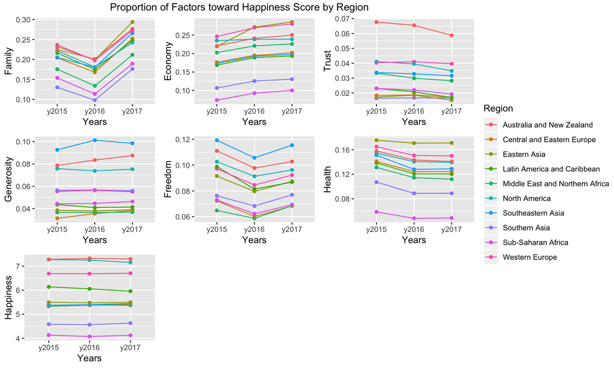

```r
names <- c('Family', 'Economy..GDP.per.Capita.', 'Trust..Government.Corruption.', 'Generosity', 'Freedom', 'Health..Life.Expectancy.', 'Happiness.Score')
plot <- list()
for (i in seq_along(names)){
  new <- region_stats(names[i], props) %>%
   gather(key = Years, value = Stat, -Region)
  plot[[i]] <- ggplot(new, aes(Years, Stat, colour = Region, group = Region)) + geom_point() + geom_line() + theme(legend.position = 'none') + ylab(str_split(names[i], "[.]")[[1]][1])
}
lemon::grid_arrange_shared_legend(plot[[1]], plot[[2]], plot[[3]], plot[[4]], plot[[5]], plot[[6]], plot[[7]], ncol = 3, nrow = 3, position='right', top = "Proportion of Factors toward Happiness Score by Region")
```

The plots above give a lot of interesting information about the relationship between the factors contributing to overall happiness and region over time. To start, by looking at the top line of each plot, it is evident that each factor tends to have different regions that have the highest proportion of that factor contributing to their happiness score. For generosity and freedom, it appears that these factors contribute most to the happiness of countries in Southeastern Asia. For trust in government, this factor contributes most to the happiness of Australia and New Zealand. For health, Eastern Asia has the highest contribution, and Sub-Saharan Africa has the lowest. Another facet of the plots to look at is the change over time. It appears that for all regions, the contribution of family to happiness scores decreased quite signifcantly in 2016, and then rose again in 2017. The contribution of freedom seems to follow the same pattern. Additionally, it is interesting to look at the single plot in the third row, which shows the total happiness score of each region over time. We see that the Australia and New Zealand, as well as North America, seem to have the top happiness scores over all three years. This is surprising since North America does not seem to have the highest contribution for any of the individual factors. Also surprising is that Eastern Asia is at the middle of the total happiness scores, although they have one of the highest contributions toward health, family, and economy.

### Figure 2

The following code creates a stacked bar chart based on an input Country for the `countries()` function defined above. During the manipulation, the data frame created from `countries()` is turned into a long dataset for ease of visualization.

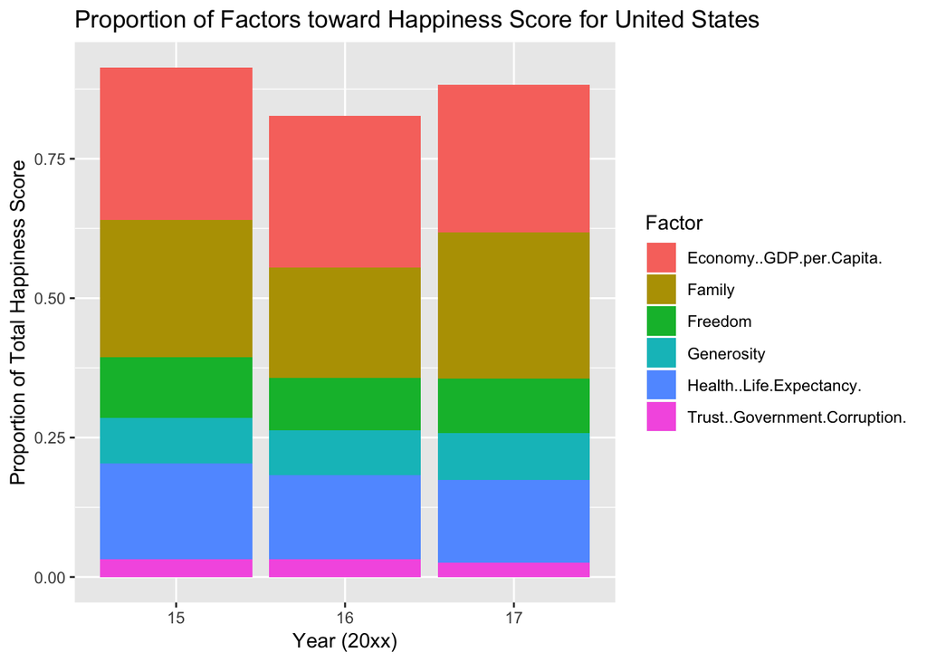

```r
country = "United States"
plotdf <- countries(country, names, props) %>% select(-Region, -starts_with('Happiness')) %>%
  gather(key = Factor, value = Prop, -Country) %>%
  mutate(Year = str_sub(Factor, -2), Factor = str_sub(Factor, 1, -5))

ggplot(plotdf, aes(Year, Prop)) + geom_bar(stat = "identity", aes(fill = Factor)) + labs(y = "Proportion of Total Happiness Score", x = "Year (20xx)", title = paste("Proportion of Factors toward Happiness Score for", plotdf[1, "Country"]))
```

The plot above shows the proportion of total happiness score the six different factors contribute for each of the three years for the United States. From the code, it is clear that the plot can be easily made for any country in the dataset by simply changing the `country` variable in the first line of this chunk of code to a different country. For the purposes of this post, we will focus on the United States. It appears from the plot that over time, most of the factors contribute to the happiness score of the US similarly. The most significant result appears to be the decrease in the family factor as a contribution to happiness in 2016. This result is not surprising based on the output of Figure 1, which showed a decrease in family contribution for all countries in 2016. It is important to note that the addition of all six factor contributions are not equal across years and do not add up to one. This is because of what they call a “dystopia residual”. Dystopia is characterized as the “least happy” country, in order to compare the others favorably to this. The dystopia residual describes the portion of a country’s happiness score that cannot be described by the other six factors considered in the data. The proportion of total happiness score of the six different factors and the proportion that the dystopia residual contributes to happiness add up to 1.

Wouldn’t it be convenient to be able to change the code and look at a different country’s plot at the click of the button? This is possible using interactive dashboards, such as `shiny` for R. In my next blog post, we will use this way of creating interactive dashboards to create a space where users can ask and answer questions about the data that is given.

## Summary of Results

In summary, coding techniques such as iteration, functions, and table joins allow for more complex manipulation of raw data in order to draw important conclusions and display them in a clear and visually appealing way. The WHR data helped to create a perfect example of this process.

The big conclusions drawn from this analysis can be seen in the figures as described above. Figure 1 gave a big picture view at the relationship between each region of the world and the factors that contribute to their happiness scores over time. Figure 2 gave a more focused view of the proportion of each factor and how they change over time for a certain country. The code can be easily altered to explore this relationship for any country, but we specifically looked at the plot for the United States.

This analysis just scratched the surface on what we could do with the information in this dataset. Interesting next steps might include looking further into why the Family and Freedom factors were low across all regions in 2016. Maybe a big event occurred this year that caused this? Maybe it was the way the question was asked that year? Many more questions than the ones offered here can be explored regarding world happiness, but this was an introduction to exploring which countries are happiest, and to what extent each of the factors contribute to that happiness.